# ANALYSIS OF DISCRETE RANDOM VARIABLES

# PROBLEM STATEMENT

- Genrate a list of values drawn from the distribution of Uniform random variable.
- Compute the sample mean and sample variance and compare it to the mean, $\mu$ and variance, $\sigma_X^2$. Estimate the (sample) variance of the sample mean (based on the Central Limit Theorem) for N=100 and N=10000.
- Repeat the same step with N=100 50 times to create a set of sample means and verify if they follow the normal distribution.
- Also check whether the consecutive values of uniform random numbers are independent or not

# THEORETICAL EXPLORATION

- $\textbf{Uniform random variable}$:For a uniform random variable X ~ U(a,b) the equations of mean and variance are as follows:
  - $E[X] = \mu = \frac{(a+b)}{2}$
  - $var(X) = \sigma_X^2 = \frac{a^2+ab+b^2}{12}$
  - Thus here we have a = 0 and b = 1 our values of $\mu$ and $\sigma_X^2$ are as follows:
    - $\mu = \frac{(0+1)}{2} = 0.5$
    - $\sigma_X^2 = \frac{0^2+0*1+1^2}{12} = 0.0833$
- $\textbf{Central Limit Theorem}$: The central limit theorem states that if we have a population with mean $\mu$ and variance $\sigma_X^2$ then if we take random samples from that population then the sample means of those samples would be normally distributed with mean $\mu$ and variance $\frac{\sigma_X^2}{n}$ where n is the size of each sample.
- $\textbf{Covariance and Correlation}$:
  - COV(X,Y) = E[X,Y] - E[X]*E[Y]
  - CORR(X,Y) = $\frac{COV(X,Y)}{\sigma_{X}\sigma_{Y}}$
  - Covariance and Correlation are measures through which we can see if two random variables are Dependent on each other.

# SIMULATION METHODOLOGY

- The first part of the program generates a uniform random sample of size 100 and 10000 using $\textbf{numpy.random.uniform}$.
- The second part calculates the mean and variance of samples with size 100 and 10000. I have also generated a uniform random pdf for N=100 and N=10k and plotted it to make point that, more data means better approximation of the ture pdf.
- The third part includes creating sampling distribution with total number of samples being 50 with sample size N=100. To give better visualization of the normality of sampling distribution another sampling distribution which has more samples than 50 is also created. Both the sampling distributions are plotted using $\textbf{matplotlib.pyplot}$.
- Finally using the same numpy library, covariance is found. To be sure of the independence, correlation is also calculated.

# EXPERIMENTS AND RESULTS

## 1.) X ~ U (0,1) , evaluate the mean, $\mu$ and variance, $\sigma_x^2$ .

```python
import numpy as np
import sklearn as sk
import scipy.stats as sci
import matplotlib.pyplot as plt
from matplotlib.font_manager import FontProperties
import matplotlib.mlab as mlab
%matplotlib inline
fontP = FontProperties()
fontP.set_size('small')
```

```python
########### Calculating mean of Uniform pdf###################
true_mean = (0+1)/2
true_variance = (1)/12
true_std = np.sqrt(true_variance)
print("Mean of true uniform random variable is: ",true_mean)
print("Variance of true uniform random variable is: ",true_variance)
```

```
Mean of true uniform random variable is:  0.5
Variance of true uniform random variable is:  0.08333333333333333
```

```python
###############Generate Uniform Random variable################
np.random.RandomState(seed=42)
X = np.random.uniform(0,1,1000)
```

- $E[X] = \mu = \frac{(a+b)}{2}$
- $var(X) = \sigma_X^2 = \frac{a^2+ab+b^2}{12}$
- Thus here we have a = 0 and b = 1 our values of $\mu$ and $\sigma_X^2$ are as follows:
  - $\mu$ = $\frac{(0+1)}{2} = 0.5$
  - $\sigma_X^2$ = $\frac{0^2+0*1+1^2}{12} = 0.0833$

| $\mu$ | $\sigma_X^2$ |
| --- | --- |
| 0.5 | 0.0833 |

## 2.) Generate a sequence of N = 100 random numbers between [0,1] and compute the sample mean,sample variance and compare to $\mu$ and variance, $\sigma_x^2$. Also estimate the (sample) variance of the sample mean (based on the Central Limit Theorem).Repeat for N =10,000.

- There are two things we need to take care of when we are considering a particular statistic of a random variable:
  - Population parameters: These parameters are mean($\mu$) and variance($\sigma_X^2$). These polupation parameters capture the real underlying mean and variance of the population. Generally speaking they are unknown to us as we will have to take the data of all the entities in order to calculate the true parameters.
    - For example: If we consider the weights of all the males in United states, we will have to measure the weights of each and every persons' weight in order to get the true mean and true variance.
  - Point Estimates: As mentioned above instead of measuring the value of each and every entity and wasting our resources we can rather sample randomly from the population and measure the mean and variance of that sample mean. This is known as sample mean(m) and sample variance($s^2$). In the example that I mentioned above a sample can be a finite or small number of males selected independently.
    - The property of this sample mean and variance is that it tends to vary around the true mean($\mu$) and true variance($\sigma_X^2$). Infact there is a trend in which if the sample size is less then the sample mean(m) tends to be far from the true mean($\mu$) and if the sample size is more then the sample mean(m) tends to be very close to the true mean($\mu$). This this is evident from the experiment that we carried above in which we used a small sample of size 100 and then a small sample of size 10000.

```python
##############Calculating mean var for N=100########################
X_100 = np.random.uniform(0, 1,100)
m_100 = np.sum(X_100)/len(X_100)
var_100 = np.sum((X_100-m_100)*(X_100-m_100))/(len(X_100)-1)
std_100 = np.sqrt(var_100)
#print('Mean of 100 random sample is: ',m_100)
#print('Variance of 100 random sample is: ',var_100)
#print('Sample variance of sample mean of size 100 is: ',var_100/100)
```

```python
##############Calculating mean var for N=10000########################
X_10k = np.random.uniform(0, 1,10000)
m_10k = np.sum(X_10k)/len(X_10k)
var_10k = np.sum((X_10k-m_10k)*(X_10k-m_10k))/(len(X_10k)-1)
std_10k = np.sqrt(var_10k)
#print('Mean of 10000 random sample is: ',m_10k)
#print('Variance of 10000 random sample is: ',var_10k)
#print('Sample variance of sample mean of size 10k is: ',var_100/10000)
```

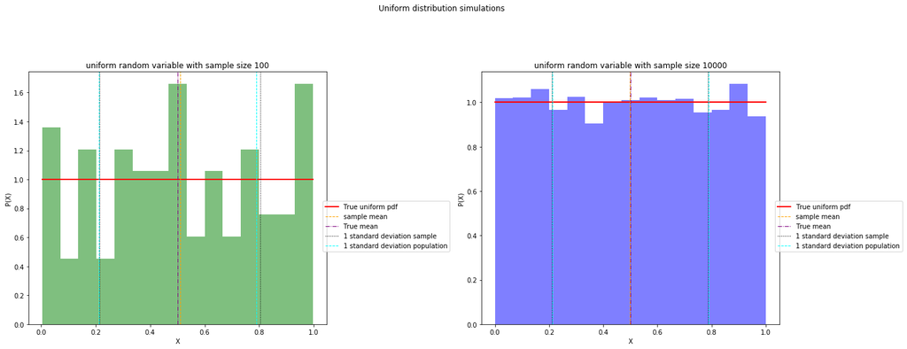

```python
###################Hist for N=100##################################
f, (ax1, ax2) = plt.subplots(1, 2,figsize=(18,8))
f.suptitle('Uniform distribution simulations')

count, bins, ignored = ax1.hist(X_100,color='green',alpha=0.5,bins=15,density=True)
ax1.plot(bins, np.ones_like(bins), linewidth=2, color='r',label='True uniform pdf')
ax1.axvline(m_100, color='orange', linestyle='dashed', linewidth=1,label='sample mean')
ax1.axvline(true_mean, color='purple', linestyle='-.', linewidth=1,label='True mean')
ax1.axvline(m_100-std_100, color='black', linestyle=':', linewidth=1,label='1 standard deviation sample')
ax1.axvline(m_100+std_100, color='black', linestyle=':', linewidth=1)
ax1.axvline(true_mean-true_std, color='cyan', linestyle='dashed', linewidth=1,label='1 standard deviation population')
ax1.axvline(true_mean+true_std, color='cyan', linestyle='dashed', linewidth=1)
ax1.set(xlabel="X",ylabel="P(X)")
ax1.legend(loc=9, bbox_to_anchor=(1.2, 0.5))
ax1.set_title('uniform random variable with sample size 100')

###################Hist for N=10000##################################
count, bins, ignored = ax2.hist(X_10k,color='blue',alpha=0.5,bins=15,density=True)
ax2.plot(bins, np.ones_like(bins), linewidth=2, color='r',label='True uniform pdf')
ax2.axvline(m_10k, color='orange', linestyle='dashed', linewidth=1,label='sample mean')
ax2.axvline(true_mean, color='purple', linestyle='-.', linewidth=1,label='True mean')
ax2.axvline(m_10k-std_10k, color='black', linestyle=':', linewidth=1,label='1 standard deviation sample')
ax2.axvline(m_10k+std_10k, color='black', linestyle=':', linewidth=1)
ax2.axvline(true_mean-true_std, color='cyan', linestyle='dashed', linewidth=1,label='1 standard deviation population')
ax2.axvline(true_mean+true_std, color='cyan', linestyle='dashed', linewidth=1)
ax2.set(xlabel="X",ylabel="P(X)")
ax2.legend(loc=9, bbox_to_anchor=(1.2, 0.5))
ax2.set_title('uniform random variable with sample size 10000')
plt.subplots_adjust(left=0.01, wspace=0.52, top=0.8)
plt.show()
```

### Results:

[output not shown]

## 3.) Verify the central limit theorem

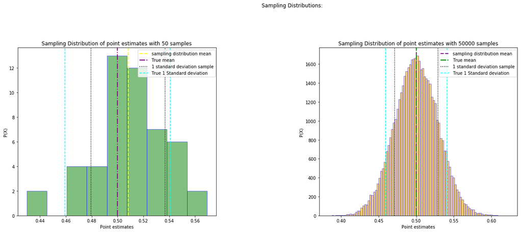

```python
#######################Calculating Point Estimates for N=50 samples##########################
point_est = []
for i in range(50):
    X = np.random.uniform(0, 1,100)
    m = np.sum(X)/len(X)
    point_est.append(m)

point_est = np.array(point_est)
mean = np.sum(point_est)/len(point_est)
var = np.sum(np.square(point_est-mean))/(len(point_est)-1)
std = np.sqrt(var)
true_sample_var = true_variance/50
true_sample_std = np.sqrt(true_sample_var)

############################Plotting distribution for 50 samples############
f, (ax1, ax2) = plt.subplots(1, 2,figsize=(18,8))
f.suptitle('Sampling Distributions: ')


weight = point_est/np.sum(point_est)
count,bins, ignored = ax1.hist(point_est,bins=9,alpha = 0.5,color = 'green',edgecolor='blue')
ax1.axvline(mean, color='yellow', linestyle='dashed', linewidth=2,label='sampling distribution mean')
ax1.axvline(true_mean, color='purple', linestyle='-.', linewidth=2,label='True mean')
ax1.axvline(mean-std, color='black', linestyle=':', linewidth=1.5,label='1 standard deviation sample')
ax1.axvline(mean+std, color='black', linestyle=':', linewidth=1.5)
l1 = 'True 1 Standard deviation'
ax1.axvline(true_mean-true_sample_std, color='cyan', linestyle='dashed', linewidth=1.5,label=l1)
ax1.axvline(true_mean+true_sample_std, color='cyan', linestyle='dashed', linewidth=1.5)
ax1.set(xlabel="Point estimates",ylabel="P(X)")
ax1.legend(loc=9, bbox_to_anchor=(0.8, 1))
ax1.set_title('Sampling Distribution of point estimates with 50 samples')

#print('Mean of point estimate is with samples 50 is: ',mean)
#print('Variance of point estimate with samples 50 is: ',var)

#######################Calculating Point Estimates for N=100 samples##########################
point_est = []
for i in range(50000):
    X = np.random.uniform(0, 1,100)
    m = np.sum(X)/len(X)
    point_est.append(m)

point_est = np.array(point_est)
mean = np.sum(point_est)/len(point_est)
var = np.sum(np.square(point_est-mean))/(len(point_est)-1)
std = np.sqrt(var)
true_sample_var = true_variance/50
true_sample_std = np.sqrt(true_sample_var)

weight = point_est/np.sum(point_est)

############################Plotting distribution for 50k samples############
count,bins, ignored = ax2.hist(point_est,bins=100,alpha = 0.5,color = 'orange',edgecolor='blue')
ax2.axvline(mean, color='purple', linestyle='dashed', linewidth=2,label='sampling distribution mean')
ax2.axvline(true_mean, color='green', linestyle='-.', linewidth=2,label='True mean')
ax2.axvline(mean-std, color='black', linestyle=':', linewidth=1.5,label='1 standard deviation sample')
ax2.axvline(mean+std, color='black', linestyle=':', linewidth=1.5)
l2 = 'True 1 Standard deviation'
ax2.axvline(true_mean-true_sample_std, color='cyan', linestyle='dashed', linewidth=1.5,label=l2)
ax2.axvline(true_mean+true_sample_std, color='cyan', linestyle='dashed', linewidth=1.5)
ax2.set(xlabel="Point estimates",ylabel="P(X)")
ax2.legend(loc=9, bbox_to_anchor=(0.8, 1))
ax2.set_title('Sampling Distribution of point estimates with 50000 samples')


#print('Mean of point estimate with sample 50k is: ',mean)
#print('Variance of point estimate with samples 50k: ',var)

plt.subplots_adjust(left=0.01, wspace=0.52, top=0.8)
plt.show()
```

[output not shown]

- The samplling distribution with 50 samples and N=100 values each has a normal distribution.
- As we can see the values of mean and sample variance are similar to the ones calculated before. We calculated the mean and sample variance for N=100 before which are almost equal to the mean and variance of this sampling distribution.
- It is not evident from the first plot that the sampling distribution has a normal shape and hence I have simulated a sampling distribution which has 50000 samples each of size 100. Such a sample clearly shows us that as we increse the number of samples this distribution tends to go towards the normal distribution.

## 4.) We want to check whether there is any dependency between $X_i$ and $X_{i+1}$

- We consider the samples to be equally likely.
- Since the sample is drawn of a uniform independent sample we expect that the covariance would be zero or very less. Covariance basically measures the linear relationship between two random variables. However two independent variables would have 0 covariance but a zero covariance does not imply that the random variables are independent. As a result of this we will also calculate the correlation whose range is between [-1,1]. If the value of correlation is 1 or -1 then there is linear relationship between the two random variables and if the value is 0 then there is no linear relationship between the random variables.
  - COV($X_i$,$X_{i+1}$) = E[$X_i$,$X_{i+1}$] - E[$X_i$]* E[$X_{i+1}$]
  - COV($X_i$,$X_{i+1}$) = $\sum_{N=1}^{\infty} \frac{X_i*X_{i+1}}{N}$ - $\sum_{N=1}^{\infty} \frac{X_i}{N}* \sum_{N=1}^{\infty} \frac{X_{i+1}}{N}$
  - CORR($X_i$,$X_{i+1}$) = $\frac{COV(X_i,X_{i+1})}{\sigma_{X_i}\sigma_{X_{i+1}}}$

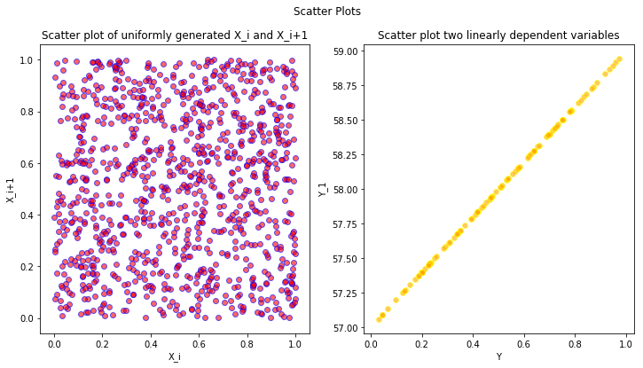

```python
########Calculating Covariance and Correlation#############
X = np.random.uniform(0,1,1001)
A=0
for i in range(1000):
    A = A + X[i]*X[i+1]
A_final = A/1000
B = (np.sum(X)-X[1000])/1000
C = (np.sum(X)-X[0])/1000
Z = A_final - (B*C)
X_i = X[0:1000]
X_i1 = X[1:1001]
std_Xi = np.std(X_i)
std_Xi_1 = np.std(X_i1)
#print("value of Covariance Z is: ",Z)
#print("Correlation is :",(Z)/(std_Xi*std_Xi_1))

#Show linear relationship
Y = np.random.uniform(0,1,100)
Y_1 = 2*Y + 57

##################Plotting scatter plots#########################
f, (ax1, ax2) = plt.subplots(1, 2,figsize=(12,6))
f.suptitle('Scatter Plots')
ax1.scatter(X_i,X_i1,color='red',alpha=0.6,edgecolors='blue')
ax1.set(xlabel='X_i', ylabel='X_i+1')
ax1.set_title('Scatter plot of uniformly generated X_i and X_i+1')

ax2.scatter(Y,Y_1,color='orange',alpha=0.6,edgecolors='yellow')
ax2.set(xlabel='Y', ylabel='Y_1')
ax2.set_title('Scatter plot two linearly dependent variables')

plt.show()
```

### Results:

| covariance(Z) | correlation |
| --- | --- |
| 0.001 | 0.016 |

- In order to show that our sample is highly uncorrelated and is independent we have created a graph of a variable which is Linearly dependent on the other.
  - The equation is: Y_1 = 2*Y + 57
  - Here Y is a uniform random sample and Y_1 is linearly dependent on Y as per the above equation.
  - As we can see from the above graphs the linearly dependent variable has a linear relationship as it is dependent on the other variable Y. The variables that we have considered i.e the random variables that take consecutive values of uniform random variable have their scatter plots all over the place which suggests that these random variables are highly uncorrelated and independent.
- As we can see from the above results the correlation and covariance, both are very near to zero. Thus we confirm our fact that the random number generator indeed generates numbers which are independent of each other and have no liner relationship between them.

# Conclusion

- The accuracy of capturing the population parameters is directly proportional to the size N of the sample.
- The sample mean and sample variance follow a normal distribution and the value of the mean of those sample means is equal to the value of the population mean.
- The random number generator used by python generates values which are not correlated to each other.